# Session 26: R lab on statistical inference

#### Modeling repeated measures

We often have data where we want to look at an effect across multiple measurements within each person. For example, in the NHANES blood pressure data that we examined in the previous session, there are actually three measurements per person. Let’s take a sample of 200 adults with all three of these measurements.

```r
set.seed(123456)
bpSample=NHANES %>%
  filter(!is.na(BPSys1) & !is.na(BPSys2) & !is.na(BPSys3) & Age>17)  %>%
  select(ID,BPSys1,BPSys2,BPSys3) %>%
  unique() %>%
  sample_n(200)

bpSampleTidy= bpSample %>%
  gather(key='measurement',value='BPSys',-ID)

bpSampleSummary=bpSampleTidy %>%
  group_by(measurement) %>%
  summarize(meanBPSys=mean(BPSys))
bpSampleSummary
```

| measurement | meanBPSys |
| --- | --- |
| BPSys1 | 122.64 |
| BPSys2 | 121.89 |
| BPSys3 | 121.01 |

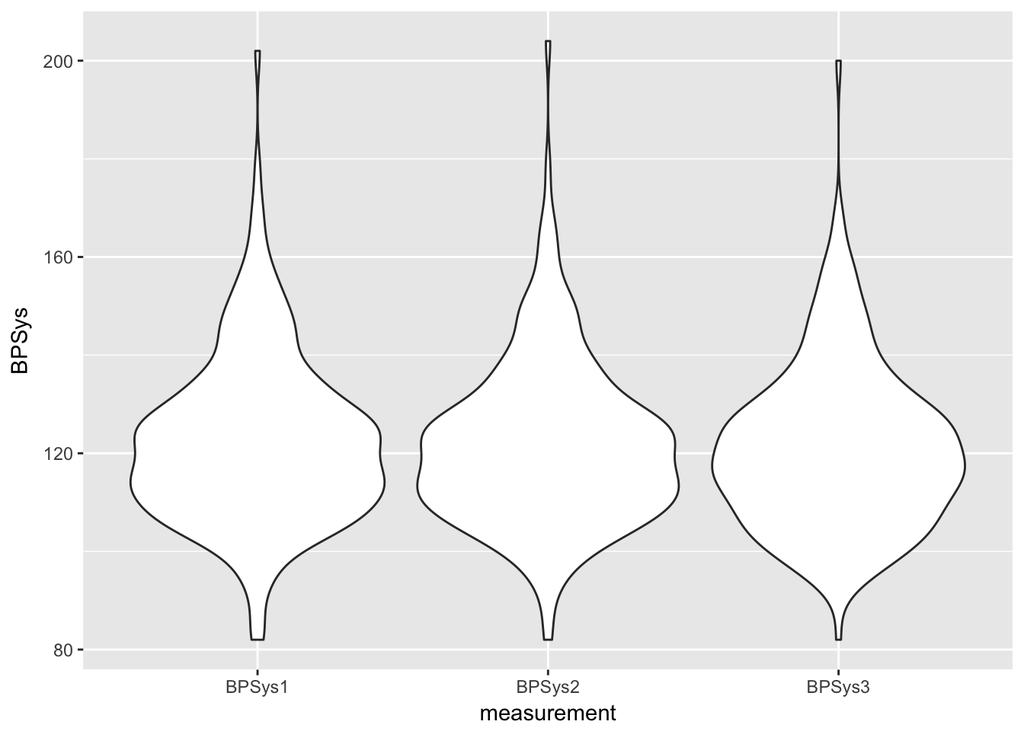

```r
ggplot(bpSampleTidy,aes(x=measurement,y=BPSys)) +
  geom_violin()
```

First set’s set up a standard ANOVA model by making dummy regressors for two of the tests. This model will ignore the fact that the measurements are related (i.e. that the same people have a measurement at each time point), which violates the IID assumption that is required to inference using this model.

```r
bpSampleTidy = bpSampleTidy %>%
  mutate(dummy1=as.integer(measurement=='BPSys2'),
         dummy2=as.integer(measurement=='BPSys3'))

lmResultIndependent=lm(BPSys ~ dummy1 + dummy2,data=bpSampleTidy)
summary(lmResultIndependent)
```

```
##
## Call:
## lm(formula = BPSys ~ dummy1 + dummy2, data = bpSampleTidy)
##
## Residuals:
##    Min     1Q Median     3Q    Max
## -40.64 -11.89  -1.89   8.11  82.11
##
## Coefficients:
##             Estimate Std. Error t value Pr(>|t|)
## (Intercept)  122.640      1.198 102.398   <2e-16 ***
## dummy1        -0.750      1.694  -0.443    0.658
## dummy2        -1.630      1.694  -0.962    0.336
## ---
## Signif. codes:  0 '***' 0.001 '**' 0.01 '*' 0.05 '.' 0.1 ' ' 1
##
## Residual standard error: 16.94 on 597 degrees of freedom
## Multiple R-squared:  0.001552,   Adjusted R-squared:  -0.001793
## F-statistic: 0.464 on 2 and 597 DF,  p-value: 0.629
```

We see that there is no significant difference in BP across the different measurements.

#### Fitting a model with a random intercept

There is a problem with the previous model, which is that it assumes that the data points are independent when we know that they are not (since each person contributes three data points). In order to address this, we need to build a model that also includes a separate intercept for each individual (which we call a *random intercept*); this will in effect remove the overall differences between individuals, leaving the errors to be independent. We can do this using the lmer() function which is part of the lme4 library; this library is a workhorse in many different areas of research, because it allows us to build and fit complex models known as “mixed effect” models. In this case, we add “+ (1|ID)” to the model. The “1” stands for an intercept, and “ID” is a variable that identifies each individual; this is effectively telling lmer() to compute a different intercept for each value of ID (i.e. each individual). Once we do this, then all of the differences in mean between subjects are modeled rather than becoming part of the error.

```r
lmRepeatedMeasures = lmer(BPSys ~ measurement + (1|ID),data=bpSampleTidy)
summary(lmRepeatedMeasures)
```

```
## Linear mixed model fit by REML t-tests use Satterthwaite approximations
##   to degrees of freedom [lmerMod]
## Formula: BPSys ~ measurement + (1 | ID)
##    Data: bpSampleTidy
##
## REML criterion at convergence: 4080.4
##
## Scaled residuals:
##      Min       1Q   Median       3Q      Max
## -2.69856 -0.52771 -0.00242  0.46332  3.04843
##
## Random effects:
##  Groups   Name        Variance Std.Dev.
##  ID       (Intercept) 273.53   16.539
##  Residual              13.36    3.655
## Number of obs: 600, groups:  ID, 200
##
## Fixed effects:
##                   Estimate Std. Error       df t value Pr(>|t|)
## (Intercept)       122.6400     1.1977 211.8000 102.398  < 2e-16 ***
## measurementBPSys2  -0.7500     0.3655 398.0000  -2.052   0.0408 *
## measurementBPSys3  -1.6300     0.3655 398.0000  -4.459 1.07e-05 ***
## ---
## Signif. codes:  0 '***' 0.001 '**' 0.01 '*' 0.05 '.' 0.1 ' ' 1
##
## Correlation of Fixed Effects:
##             (Intr) msBPS2
## msrmntBPSy2 -0.153
## msrmntBPSy3 -0.153  0.500
```

We can get a printout of the overall (“omnibus”) F statistic comparing all of the different means, using the anova() function:

```r
anova(lmRepeatedMeasures)
```

|  | Sum Sq | Mean Sq | NumDF | DenDF | F.value | Pr(>F) |
| --- | --- | --- | --- | --- | --- | --- |
| measurement | 266.2533 | 133.1267 | 2 | 398.0009 | 9.963696 | 5.993278e-05 |

This mode shows that there is a statistically significant effect of the different measurements.

#### Bayesian modeling of ANOVA

We can also use a Bayesian model to perform the same analysis, via the brm() function from the brms package. This has the advantage of giving us results that allow us to directly estimate our confidence in the parameter values. It uses the same formula specification as lmer(). This analysis takes a bit longer and prints lots of intermediate outputs about the sampling process:

```r
brmRepeatedMeasures = brm(BPSys ~ measurement + (1|ID),data=bpSampleTidy,save_all_pars=TRUE)
```

[output not shown]

[output cut: 40 more lines]

[output not shown]

The fitting of the models prints out a bunch of interim information, but now we can look at the output using summary():

```r
summary(brmRepeatedMeasures)
```

```
##  Family: gaussian
##   Links: mu = identity; sigma = identity
## Formula: BPSys ~ measurement + (1 | ID)
##    Data: bpSampleTidy (Number of observations: 600)
## Samples: 4 chains, each with iter = 2000; warmup = 1000; thin = 1;
##          total post-warmup samples = 4000
##     ICs: LOO = NA; WAIC = NA; R2 = NA
##
## Group-Level Effects:
## ~ID (Number of levels: 200)
##               Estimate Est.Error l-95% CI u-95% CI Eff.Sample Rhat
## sd(Intercept)    16.61      0.88    15.02    18.46        171 1.03
##
## Population-Level Effects:
##                   Estimate Est.Error l-95% CI u-95% CI Eff.Sample Rhat
## Intercept           122.76      1.09   120.72   124.98        151 1.02
## measurementBPSys2    -0.74      0.36    -1.44    -0.02       4000 1.00
## measurementBPSys3    -1.62      0.37    -2.33    -0.88       4000 1.00
##
## Family Specific Parameters:
##       Estimate Est.Error l-95% CI u-95% CI Eff.Sample Rhat
## sigma     3.66      0.13     3.42     3.93       4000 1.00
##
## Samples were drawn using sampling(NUTS). For each parameter, Eff.Sample
## is a crude measure of effective sample size, and Rhat is the potential
## scale reduction factor on split chains (at convergence, Rhat = 1).
```

What if we want to test the equivalent of the “omnibus” hypothesis that we tested using the F test in our lmer() model? One way to do this is by comparing the fit of our model with a similar model that doesn’t include the measurement factor; it just includes the intercepts computed separately for each individual. We can fit that model here, which we call the “reduced” model. We can then compute the Bayes factor to compare these models, which tells us how likely the data are under the full model compared to the reduced model - that is, how much more plausible is the model that includes the measurement variable, compared to not including it:

```r
brmReduced=brm(BPSys ~ (1|ID),data=bpSampleTidy,save_all_pars=TRUE)
```

[output not shown]

[output cut: 40 more lines]

[output not shown]

```r
bayes_factor(brmRepeatedMeasures,brmReduced)
```

[output not shown]

```
## The estimated Bayes factor in favor of x1 over x2 is equal to: 4371.768
```

We see that the evidence in favor including the measurement variable in the model is very strong, telling us that there are very likely to be differences in blood pressure between the different measurements.

#### Multi-way ANOVA

So far we have only looked at ANOVA models that include a single factor (such as the different measurements in the previous case). However, we often want to look at relationships between discrete variables. As an example, let’s say that we want to understand how the factors of smoking and physical activity relate to BMI in the NHANES data. Here we can test three different hypotheses:

- Is there a relationship between smoking on BMI?
- Is there a relationship between physical activity and BMI?
- Is there an interaction? That is, does the effect of smoking on BMI differ depending on level of physical activity?

Let’s look at this in a sample from NHANES. We first have to do a bit of data wrangling: The SmokeNow variable is only reported for people who said yes to having smoked at least 100 cigarettes in their life. Thus, the people who say “no” to SmokeNow are former smokers, and we can imagine that many of them quit because of health problems. We can fix this by removing the former smokers, and then looking at the Smoke100 variable; that is, we only consider someone as a smoker if they both say yes to Smoke100 and to SmokeNow. Former smokers are left out of this analysis.

```r
set.seed(123456)
bp2waySample=NHANES %>%
  filter(!is.na(BMI) & !is.na(PhysActive) & !is.na(Smoke100) & Age>17)  %>%
  filter(SmokeNow=='Yes' | is.na(SmokeNow)) %>%
  mutate(Smoker=ifelse(Smoke100=='No','No','Yes')) %>%
  select(ID,BMI,PhysActive,Smoker) %>%
  unique() %>%
  sample_n(400)


bp2waySummary=bp2waySample %>%
  group_by(Smoker,PhysActive) %>%
  summarize(meanBMI=mean(BMI),
            n=n(),
            varBMI=var(BMI)) %>%
  mutate(crit_val_lower = qt(.05, n - 1),
         crit_val_upper = qt(.95, n - 1),
         ci.lower=meanBMI+(sqrt(varBMI)*crit_val_lower)/sqrt(n),
         ci.upper=meanBMI+(sqrt(varBMI)*crit_val_upper)/sqrt(n))

bp2waySummary
```

| Smoker | PhysActive | meanBMI | n | varBMI | crit_val_lower | crit_val_upper | ci.lower | ci.upper |
| --- | --- | --- | --- | --- | --- | --- | --- | --- |
| No | No | 31.16489 | 135 | 46.46751 | -1.656305 | 1.656305 | 30.19315 | 32.13662 |
| No | Yes | 27.57377 | 162 | 38.66830 | -1.654373 | 1.654373 | 26.76550 | 28.38203 |
| Yes | No | 28.26492 | 59 | 34.07105 | -1.671553 | 1.671553 | 26.99467 | 29.53516 |
| Yes | Yes | 28.38545 | 44 | 34.30935 | -1.681071 | 1.681071 | 26.90100 | 29.86991 |

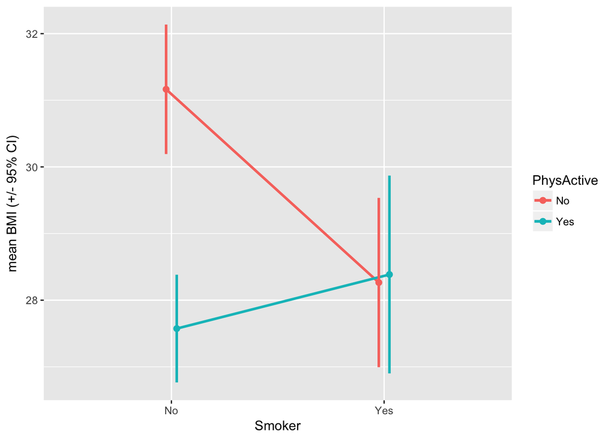

```r
pd=position_dodge(0.1)
ggplot(bp2waySummary,aes(x=Smoker,y=meanBMI,color=PhysActive,group=PhysActive)) +
  geom_line(size=1,position=pd) +
  geom_point(size=2,position = pd) +
  geom_errorbar(aes(ymin = ci.lower, ymax = ci.upper), width = 0, size = 1,position=pd) +
  ylab('mean BMI (+/- 95% CI)')
```

Now let’s fit a two-way ANOVA model that includes both smoking and physical activity. We build the model using lm(): note that we can say “PhysActive*Smoker" and lm() will understand that we also want to include the main effects as well, such that the model will really be “PhysActive + Smoker + PhysActive x Smoker”.

```r
lmResult2way=lm(BMI ~ PhysActive*Smoker,data=bp2waySample )
summary(lmResult2way)
```

```
##
## Call:
## lm(formula = BMI ~ PhysActive * Smoker, data = bp2waySample)
##
## Residuals:
##      Min       1Q   Median       3Q      Max
## -10.8849  -4.2842  -0.9849   3.2501  30.6062
##
## Coefficients:
##                         Estimate Std. Error t value Pr(>|t|)
## (Intercept)              31.1649     0.5454  57.139  < 2e-16 ***
## PhysActiveYes            -3.5911     0.7385  -4.863 1.67e-06 ***
## SmokerYes                -2.9000     0.9890  -2.932  0.00356 **
## PhysActiveYes:SmokerYes   3.7117     1.4625   2.538  0.01153 *
## ---
## Signif. codes:  0 '***' 0.001 '**' 0.01 '*' 0.05 '.' 0.1 ' ' 1
##
## Residual standard error: 6.337 on 396 degrees of freedom
## Multiple R-squared:  0.05974,    Adjusted R-squared:  0.05262
## F-statistic: 8.387 on 3 and 396 DF,  p-value: 2.036e-05
```

This shows that there is a significant interaction between the two factors, such that the effect of physical activity on BMI differs between smokers and nonsmokers. If we examine the figure we can interpret this more clearly; There seems to be a large effect of physical activity for non-smokers, but not for smokers. Note that there are also significant main effects of both PhysActive and Smoker, but these must be interpreted with caution because of the presence of the interaction; they basically tell us that there is an effect, conditional on the values of the other effects.

We can look more closely at the means for each condition to determine what is going on. In particular, we can do a “post-hoc” test to see which of the individual conditions are different from one another, using the emmeans() function from the emmeans (“estimated marginal means”) package. This computes a statistical test between each of the pairs of means, and then tells us which are different from which others.

```r
# compute the differences between each of the means
leastsquare = emmeans(lmResult2way,
                      pairwise ~ PhysActive:Smoker,
                      adjust="tukey")

# display the results by grouping using letters

cld(leastsquare,
    alpha=.05,
    Letters=letters)$emmeans
```

|  | PhysActive | Smoker | emmean | SE | df | lower.CL | upper.CL | .group |
| --- | --- | --- | --- | --- | --- | --- | --- | --- |
| 2 | Yes | No | 27.57377 | 0.4979016 | 396 | 26.59490 | 28.55263 | a |
| 3 | No | Yes | 28.26492 | 0.8250400 | 396 | 26.64291 | 29.88692 | a |
| 4 | Yes | Yes | 28.38545 | 0.9553768 | 396 | 26.50721 | 30.26370 | ab |
| 1 | No | No | 31.16489 | 0.5454239 | 396 | 30.09260 | 32.23718 | b |

Any two conditions that share one or more of the same grouping letters are not significantly different from one another, after correcting for the multiple tests. In this case, Yes/Yes and No/No are not significant different from another another (both are in group b), while No/No is signficantly different from Yes/No and No/Yes.

#### Bayesian 2-way anova

Let’s fit the same model using our Bayesian approach:

```r
brmResult2way=brm(BMI ~ PhysActive*Smoker,data=bp2waySample,save_all_pars = TRUE)
```

[output not shown]

[output cut: 40 more lines]

[output not shown]

```r
summary(brmResult2way)
```

```
##  Family: gaussian
##   Links: mu = identity; sigma = identity
## Formula: BMI ~ PhysActive * Smoker
##    Data: bp2waySample (Number of observations: 400)
## Samples: 4 chains, each with iter = 2000; warmup = 1000; thin = 1;
##          total post-warmup samples = 4000
##     ICs: LOO = NA; WAIC = NA; R2 = NA
##
## Population-Level Effects:
##                         Estimate Est.Error l-95% CI u-95% CI Eff.Sample
## Intercept                  31.16      0.55    30.11    32.25       3376
## PhysActiveYes              -3.59      0.75    -5.05    -2.16       3764
## SmokerYes                  -2.91      0.99    -4.82    -0.92       2905
## PhysActiveYes:SmokerYes     3.70      1.46     0.84     6.53       3063
##                         Rhat
## Intercept               1.00
## PhysActiveYes           1.00
## SmokerYes               1.00
## PhysActiveYes:SmokerYes 1.00
##
## Family Specific Parameters:
##       Estimate Est.Error l-95% CI u-95% CI Eff.Sample Rhat
## sigma     6.35      0.23     5.92     6.81       4000 1.00
##
## Samples were drawn using sampling(NUTS). For each parameter, Eff.Sample
## is a crude measure of effective sample size, and Rhat is the potential
## scale reduction factor on split chains (at convergence, Rhat = 1).
```

Here again we can compute a Bayes Factor to compare two different models; in this case, let’s compare the model containing an interaction (the one fitted above) to an “additive” model that only include main effects.

```r
brmResult2wayAdditive=brm(BMI ~ PhysActive + Smoker,data=bp2waySample,save_all_pars = TRUE)
```

[output not shown]

[output cut: 40 more lines]

[output not shown]

```r
bayes_factor(brmResult2way,brmResult2wayAdditive)
```

```
## Iteration: 1
## Iteration: 2
## Iteration: 3
## Iteration: 4
## Iteration: 1
## Iteration: 2
## Iteration: 3
## Iteration: 4
```

```
## The estimated Bayes factor in favor of x1 over x2 is equal to: 90.26122
```